# Describing and comparing documents

```r
library(quanteda)
```

```r
library(quanteda.textstats)
library(quanteda.textplots)
```

# Lexical diversity

`textstat_lexdiv()` calculates various measures of lexical diversity based on the number of unique types of tokens and the length of a document. It is useful for analyzing speakers’ or writers’ linguistic skill, or complexity of ideas expressed in documents.

```r
# creating DFM for corpus of inaugural speeches
dfmat_inaug <- dfm(tokens(data_corpus_inaugural),
                   verbose=TRUE)
```

```
## Creating a dfm from a tokens input...
```

```
##  ...lowercasing
```

```
##  ...found 59 documents, 9,439 features
```

```
##  ...complete, elapsed time: 0.262 seconds.
```

```
## Finished constructing a 59 x 9,439 sparse dfm.
```

```r
# removing stopwords
dfmat_inaug <- dfm_remove(dfmat_inaug, stopwords('english'))
tstat_lexdiv <- textstat_lexdiv(dfmat_inaug)
tail(tstat_lexdiv, 5)
```

```
##      document       TTR
## 55  2005-Bush 0.6176753
## 56 2009-Obama 0.6828645
## 57 2013-Obama 0.6605238
## 58 2017-Trump 0.6409537
## 59 2021-Biden 0.5572316
```

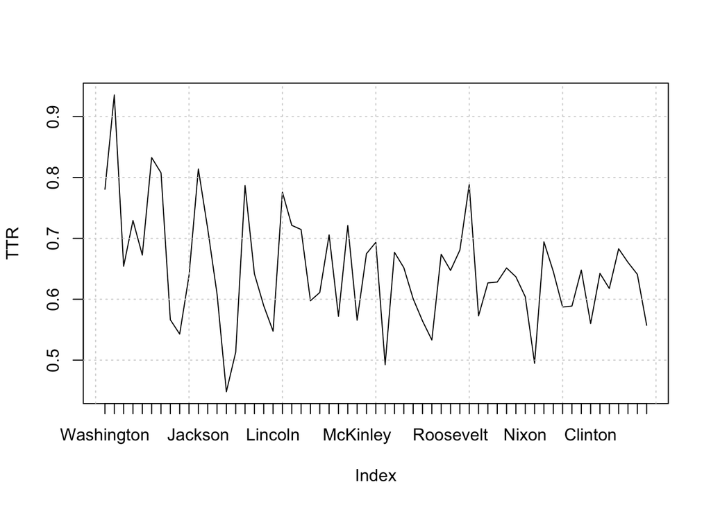

```r
plot(tstat_lexdiv$TTR, type = 'l', xaxt = 'n',
     xlab = NULL, ylab = "TTR")
grid()
axis(1, at = seq_len(nrow(tstat_lexdiv)), labels = docvars(dfmat_inaug, 'President'))
```

# Readability

`textstat_readability()` computes a metric of document complexity based on characteristics of the text such as number of words, sentence length, number of syllables, etc.

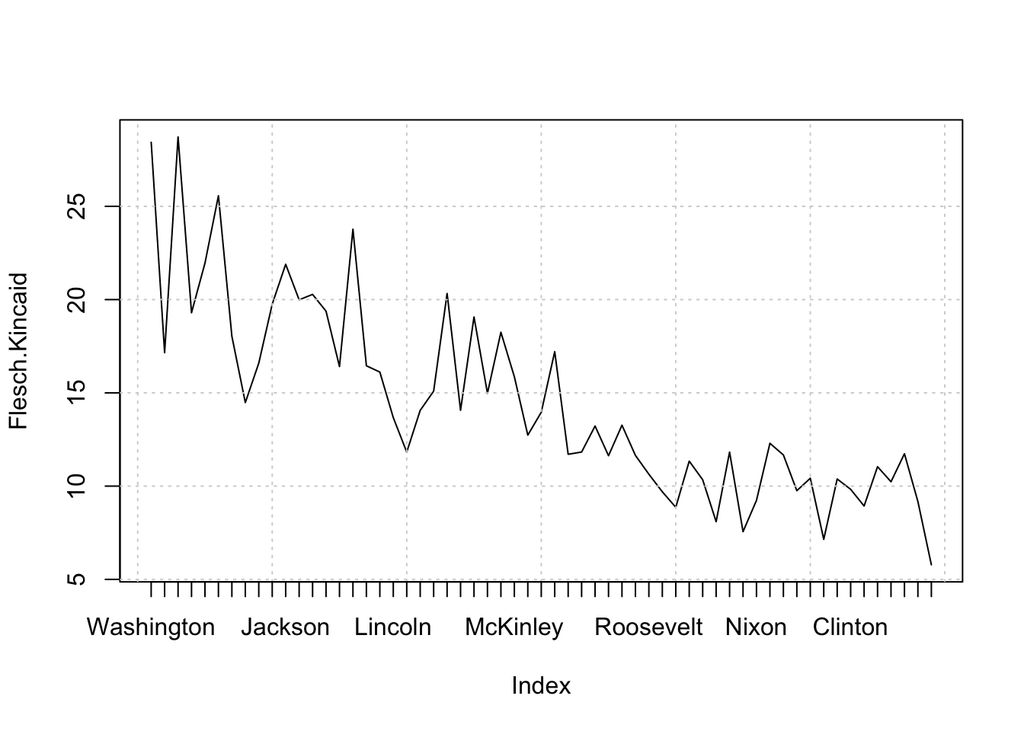

```r
stat_read <- textstat_readability(data_corpus_inaugural,
                     measure = c("Flesch.Kincaid", "FOG"))
plot(stat_read$Flesch.Kincaid, type = 'l', xaxt = 'n', xlab = NULL, ylab = "Flesch.Kincaid")
grid()
axis(1, at = seq_len(nrow(stat_read)),
     labels = docvars(dfmat_inaug, 'President'))
```

# Distance metrics

`textstat_simil()` computes matrices of distances and similarities between documents. It is useful for comparing the feature use across different documents.

Euclidean distance:

```r
docs <- c("this is document one", "this is document two")
(doc_dfm <- dfm(tokens(docs)))
```

```
## Document-feature matrix of: 2 documents, 5 features (20.00% sparse) and 0 docvars.
##        features
## docs    this is document one two
##   text1    1  1        1   1   0
##   text2    1  1        1   0   1
```

```r
textstat_dist(doc_dfm, method="euclidean")
```

```
## textstat_dist object; method = "euclidean"
##       text1 text2
## text1     0  1.41
## text2  1.41     0
```

```r
# let's do the math...
(d1 <- as.numeric(doc_dfm[1,]))
```

```
## [1] 1 1 1 1 0
```

```r
(d2 <- as.numeric(doc_dfm[2,]))
```

```
## [1] 1 1 1 0 1
```

```r
sqrt(sum((d1 - d2)^2))
```

```
## [1] 1.414214
```

Cosine similarity:

```r
textstat_simil(doc_dfm, method="cosine")
```

```
## textstat_simil object; method = "cosine"
##       text1 text2
## text1  1.00  0.75
## text2  0.75  1.00
```

```r
# some more math...
sum(d1 * d2) / ( sqrt(sum(d1^2)) *  sqrt(sum(d2^2)) )
```

```
## [1] 0.75
```

Note that these two metrics measure the opposite thing: Euclidean distance measures how *different* documents are, whereas cosine similarity measures how *similar* documents are. Of course, it’s easy to reverse them; generally, we can just say (1 - distance) = similarity.

And here’s an example of how we would apply these metrics in practice. Let’s say I want to build a recommendation engine for Taylor Swift songs.

```r
library(readr)
ts <- read_csv("../data/taylor_swift_lyrics.csv")
# now we find a song I like
song <- which(ts$Title=="You Need To Calm Down")
ts[song,]
```

```
## # A tibble: 1 x 4
##   Artist     Album Title          Lyrics
##   <chr>      <chr> <chr>          <chr>
## 1 Taylor Sw… Lover You Need To C… "You are somebody that I don't know\nBut you'…
```

```r
# pre-process the data
corp <- corpus(ts, text_field = "Lyrics")
docnames(corp) <- docvars(corp)$Title
toks <- tokens(corp, remove_punct=TRUE, remove_numbers=TRUE)
tdfm <- dfm(toks, verbose=TRUE, remove=stopwords("english"))
```

```
## Creating a dfm from a tokens input...
```

```
##  ...lowercasing
```

```
##  ...found 132 documents, 3,052 features
```

```
## ...
```

```
## removed 161 features
##  ...complete, elapsed time: 0.026 seconds.
## Finished constructing a 132 x 2,891 sparse dfm.
```

```r
# and I will compute cosine similarity with respect to all other movies
simil <- textstat_simil(x=tdfm,
                        y=tdfm[song,], method="cosine")
simil <- simil[order(simil, decreasing=TRUE),]
head(simil, n=5)
```

```
##                   You Need To Calm Down We Are Never Ever Getting Back Together
##                               1.0000000                               0.3860419
##                          State of Grace                       Come Back Be Here
##                               0.2801466                               0.2408928
##                               Invisible
##                               0.2376642
```

```r
# and we can read their lyrics
message(ts$Lyrics[ts$Title == names(simil)[2]])
```

```
## I remember when we broke up, the first time
## Saying, "This is it, I've had enough"
## 'Cause like we hadn't seen each other in a month
## When you, said you, needed space (what?)
## Then you come around again and say
## "Baby, I miss you and I swear I'm gonna change, trust me"
## Remember how that lasted for a day?
## I say, I hate you, we break up, you call me, I love you
## Ooh, oh-oh, oh-oh
## We called it off again last night
## But ooh, oh-oh, oh-oh
## This time I'm telling you, I'm telling you
## We are never ever, ever getting back together
## We are never ever, ever getting back together
## You go talk to your friends, talk to my friends, talk to me
## But we are never ever, ever, ever getting back together
## Like, ever
## I'm really gonna miss you picking fights
## And me, falling for it screaming that I'm right
## And you, would hide away and find your peace of mind
## With some indie record that's much cooler than mine
## Ooh, oh-oh, oh-oh
## You called me up again tonight
## But ooh, oh-oh, oh-oh
## This time I'm telling you, I'm telling you
## We are never ever, ever getting back together
## We are never ever, ever getting back together
## You go talk to your friends, talk to my friends, talk to me (talk to me)
## But, we are never ever, ever, ever getting back together
## Ooh, oh-oh, oh-oh yeah
## Ooh, oh-oh, oh-oh-oh yeah
## Ooh, oh-oh, oh-oh yeah
## Oh-oh-oh
## I used to think that we were forever ever, ever
## And I used to say, "Never say never"
## "Huh, so he calls me up and he's like, I still love you
## And I'm like I just I mean this is exhausting, you know
## Like we are never getting back together like, ever"
## We are never ever, ever getting back together
## We are never ever, ever getting back together
## You go talk to your friends, talk to my friends, talk to me
## But we are never ever ever ever getting back together
## (We) ooh, oh-oh, oh-oh
## Ooh, oh-oh, oh-oh (getting back together)
## (We) ooh, oh-oh, oh-oh
## Ooh, oh-oh, oh-oh (getting back together)
## You go talk to your friends, talk to my friends, talk to me (talk to me)
## But we are never ever, ever, ever getting back together
```

## Identifying most unique features of documents

*Keyness* is a measure of to what extent some features are specific to a (group of) document in comparison to the rest of the corpus, taking into account that some features may be too rare.

```r
# Donald Trump
head(textstat_keyness(dfmat_inaug, target="2017-Trump",
                      measure="chi2"), n=20)
```

```
##         feature      chi2            p n_target n_reference
## 1         obama 175.47131 0.000000e+00        3           0
## 2       america  98.56898 0.000000e+00       18         184
## 3   politicians  94.45425 0.000000e+00        2           0
## 4         stops  94.45425 0.000000e+00        2           0
## 5  transferring  94.45425 0.000000e+00        2           0
## 6     trillions  94.45425 0.000000e+00        2           0
## 7      everyone  89.53885 0.000000e+00        4           7
## 8        dreams  88.59008 0.000000e+00        5          13
## 9          jobs  68.89993 1.110223e-16        4          10
## 10         back  68.70331 1.110223e-16        6          27
## 11    protected  67.46086 2.220446e-16        5          18
## 12     mountain  61.97813 3.441691e-15        2           1
## 13      winning  61.97813 3.441691e-15        2           1
## 14    factories  55.21629 1.080247e-13        3           6
## 15       across  51.74990 6.303846e-13        5          24
## 16      borders  49.21176 2.297718e-12        3           7
## 17       breath  45.74596 1.346268e-11        2           2
## 18    victories  45.74596 1.346268e-11        2           2
## 19     american  36.39465 1.611451e-09       11         161
## 20    righteous  36.01137 1.961690e-09        2           3
```

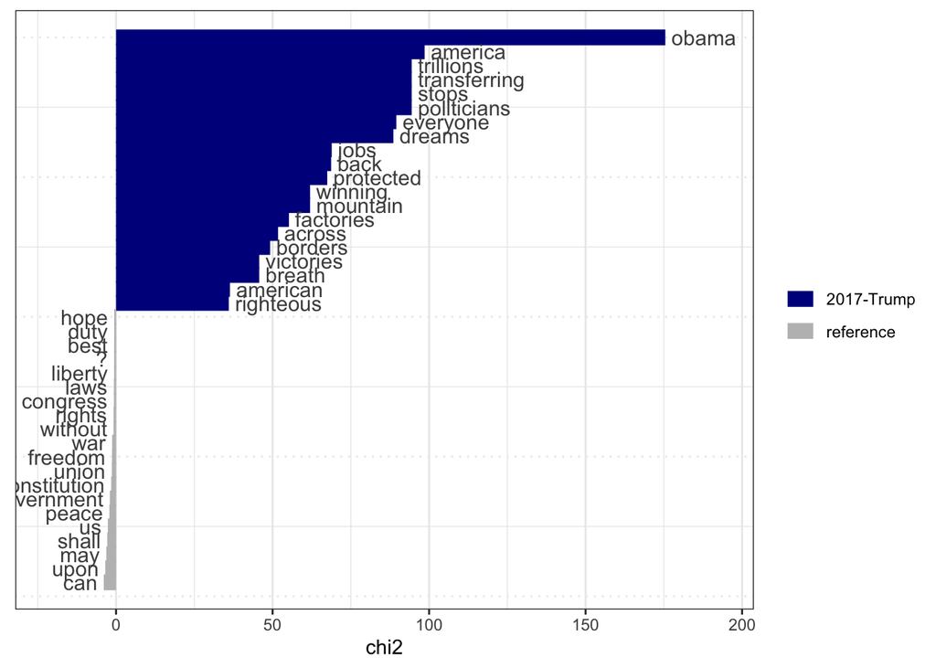

```r
textplot_keyness(textstat_keyness(dfmat_inaug, target="2017-Trump",
                      measure="chi2"))
```

```r
# Joe Biden
head(textstat_keyness(dfmat_inaug, target="2021-Biden",
                      measure="chi2"), n=20)
```

```
##         feature      chi2            p n_target n_reference
## 1         virus 155.77280 0.000000e+00        4           0
## 2         story 150.17410 0.000000e+00        9          14
## 3             . 136.22694 0.000000e+00      210        4945
## 4       uniting 105.72925 0.000000e+00        3           0
## 5           cry  78.05765 0.000000e+00        3           1
## 6         unity  66.28899 4.440892e-16        8          29
## 7  disagreement  56.79464 4.840572e-14        2           0
## 8     extremism  56.79464 4.840572e-14        2           0
## 9        harris  56.79464 4.840572e-14        2           0
## 10     pandemic  56.79464 4.840572e-14        2           0
## 11       versus  56.79464 4.840572e-14        2           0
## 12    democracy  52.56633 4.160006e-13       10          58
## 13      america  48.99512 2.565947e-12       18         184
## 14         days  46.78806 7.909340e-12        6          22
## 15         soul  43.22394 4.881962e-11        4           9
## 16          get  42.51329 7.020373e-11        3           4
## 17    prevailed  42.51329 7.020373e-11        3           4
## 18      another  40.52155 1.944591e-10        9          59
## 19       racism  36.87656 1.258497e-09        2           1
## 20         lost  33.88868 5.835730e-09        4          12
```

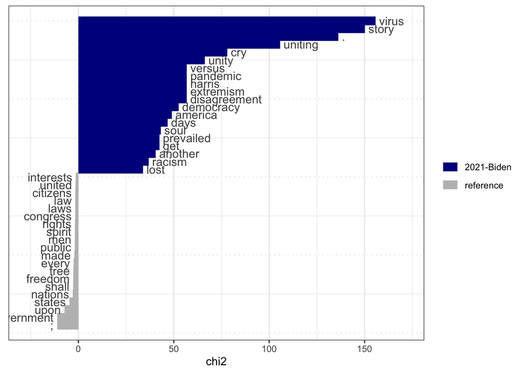

```r
textplot_keyness(textstat_keyness(dfmat_inaug, target="2021-Biden",
                      measure="chi2"))
```

Another example using song lyrics:

```r
head(textstat_keyness(tdfm,
                      target=docvars(tdfm, "Album")=="reputation"), n=20)
```

```
##       feature      chi2            p n_target n_reference
## 1          ha 156.72632 0.000000e+00       38          14
## 2        made 139.89533 0.000000e+00       51          40
## 3     getaway 126.14359 0.000000e+00       21           0
## 4     endgame  94.39328 0.000000e+00       16           0
## 5    delicate  87.03835 0.000000e+00       16           1
## 6         ooh  70.48511 0.000000e+00       36          42
## 7    gorgeous  69.02227 1.110223e-16       12           0
## 8        usin  69.02227 1.110223e-16       12           0
## 9        look  67.25179 2.220446e-16       46          70
## 10      hands  58.25555 2.298162e-14       23          20
## 11 reputation  55.74006 8.271162e-14       11           1
## 12       tied  54.92990 1.249001e-13       15           6
## 13       call  51.41185 7.488454e-13       26          30
## 14      begin  46.21898 1.057476e-11       12           4
## 15       rest  43.87590 3.498701e-11       10           2
## 16        car  43.63204 3.962974e-11       21          23
## 17       doin  43.35604 4.563261e-11        9           1
## 18       lord  43.35604 4.563261e-11        9           1
## 19      games  40.68419 1.789292e-10       13           7
## 20     bought  39.11303 3.999664e-10       10           3
```

```r
head(textstat_keyness(tdfm,
                      target=docvars(tdfm, "Album")=="folklore"), n=20)
```

```
##      feature     chi2            p n_target n_reference
## 1      woman 88.90694 0.000000e+00       11           0
## 2       gave 67.24075 2.220446e-16       17          13
## 3     pulled 62.24728 2.997602e-15        9           1
## 4     showed 59.75524 1.076916e-14       11           4
## 5      signs 57.23415 3.863576e-14       10           3
## 6       film 44.93604 2.035760e-11        7           1
## 7     august 44.27899 2.847556e-11        6           0
## 8   breathin 44.27899 2.847556e-11        6           0
## 9       seen 40.71022 1.765617e-10       12          11
## 10   warning 36.41510 1.594633e-09        6           1
## 11      give 35.83813 2.144101e-09       12          13
## 12     betty 35.40615 2.676408e-09        5           0
## 13   ruining 35.40615 2.676408e-09        5           0
## 14  would've 32.91234 9.640922e-09        9           7
## 15 marvelous 29.32065 6.133858e-08        7           4
## 16 someone's 28.04325 1.186342e-07        5           1
## 17     angry 26.58024 2.528159e-07        4           0
## 18    assume 26.58024 2.528159e-07        4           0
## 19  cardigan 26.58024 2.528159e-07        4           0
## 20   cursing 26.58024 2.528159e-07        4           0
```

# Clustering methods

Let’s explore an application of k-means clustering to the same lyrics dataset:

```r
cdfm <- dfm_weight(dfm_trim(tdfm, min_docfreq = 5, verbose=TRUE), "prop")
```

```
## Removing features occurring:
```

```
##   - in fewer than 5 documents: 2,390
```

```
##   Total features removed: 2,390 (82.7%).
```

```r
set.seed(777) # set random seed to ensure replicability
kc <- kmeans(cdfm, centers=5)
table(kc$cluster)
```

```
##
##  1  2  3  4  5
## 13  3 11 84 21
```

```r
head(docvars(tdfm, "Title")[kc$cluster==1])
```

```
## [1] "Untouchable"
## [2] "Haunted"
## [3] "If This Was a Movie"
## [4] "Red"
## [5] "We Are Never Ever Getting Back Together"
## [6] "Starlight"
```

```r
head(docvars(tdfm, "Title")[kc$cluster==2])
```

```
## [1] "Stay Stay Stay"             "Welcome to New York"
## [3] "All You Had to Do Was Stay"
```

```r
head(docvars(tdfm, "Title")[kc$cluster==3])
```

```
## [1] "A Place in This World"   "The Outside"
## [3] "Stay Beautiful"          "Love Story"
## [5] "Mine"                    "I Knew You Were Trouble"
```

```r
head(docvars(tdfm, "Title")[kc$cluster==4])
```

```
## [1] "Tim McGraw"                 "Picture to Burn"
## [3] "Teardrops on my Guitar"     "Cold As You"
## [5] "Tied Together With A Smile" "Should’ve Said No"
```

```r
head(docvars(tdfm, "Title")[kc$cluster==5])
```

```
## [1] "I’m Only Me When I’m With You" "Invisible"
## [3] "Come In With the Rain"         "Fearless"
## [5] "You Belong With Me"            "Breathe"
```

```r
# Taylor is upset?
head(textstat_keyness(cdfm, target=kc$cluster==1),n=10)
```

```
##     feature      chi2         p   n_target n_reference
## 1      wish 2.2741471 0.1315475 0.36419554  0.13055500
## 2     oh-oh 2.1768565 0.1401004 0.38811880  0.18391323
## 3       red 1.7708796 0.1832733 0.29541741  0.11836669
## 4      made 1.3207870 0.2504509 0.33411401  0.29880745
## 5      like 0.8921105 0.3449060 0.81060432  2.37874668
## 6      back 0.6316675 0.4267443 0.49101770  1.29921979
## 7     dream 0.5360993 0.4640538 0.11558694  0.07973952
## 8  together 0.3906965 0.5319335 0.11641229  0.12922124
## 9       mad 0.3336997 0.5634887 0.14316912  0.23595318
## 10  burning 0.3212358 0.5708659 0.06014595  0.03153234
```

```r
# Songs about staying?
head(textstat_keyness(cdfm, target=kc$cluster==2),n=10)
```

```
##     feature       chi2           p   n_target n_reference
## 1      stay 10.6353667 0.001109453 0.44679487  0.33690834
## 2      york  8.5503027 0.003454648 0.25862069  0.07411648
## 3       new  5.6015308 0.017944792 0.29310345  0.33479497
## 4       mad  1.3576586 0.243943687 0.11538462  0.26373768
## 5      beat  0.5835237 0.444934443 0.04310345  0.08206886
## 6     quite  0.4920183 0.483028355 0.03846154  0.07888640
## 7     funny  0.4178591 0.518007228 0.03076923  0.05831708
## 8       hey  0.3497476 0.554256031 0.05555556  0.24949022
## 9  could've  0.2554360 0.613273193 0.02777778  0.08448445
## 10     easy  0.2059557 0.649955953 0.02777778  0.10610563
```

```r
# You're to blame songs?
head(textstat_keyness(cdfm, target=kc$cluster==3),n=10)
```

```
##    feature      chi2         p   n_target n_reference
## 1       oh 2.0314121 0.1540774 1.31006081  1.11591530
## 2     love 0.7486091 0.3869170 0.50241541  1.49838599
## 3     girl 0.4657395 0.4949538 0.19222788  0.39049828
## 4     ever 0.4305819 0.5117036 0.26243662  0.72850360
## 5    blame 0.3667422 0.5447854 0.05545444  0.02843651
## 6     save 0.3455795 0.5566262 0.08310857  0.09406736
## 7   walked 0.2927459 0.5884663 0.06779661  0.07293407
## 8     life 0.2492036 0.6176364 0.12437625  0.29616419
## 9      yes 0.1967059 0.6573930 0.06041952  0.09153650
## 10   ain't 0.1964218 0.6576247 0.10302559  0.25497750
```

```r
# Rest of songs
head(textstat_keyness(cdfm, target=kc$cluster==4),n=10)
```

```
##    feature      chi2         p  n_target n_reference
## 1       ah 0.2091472 0.6474366 0.3960756 0.007142857
## 2     nice 0.1777344 0.6733276 0.3419052 0.007299270
## 3    knows 0.1743036 0.6763151 0.3388343 0.008000000
## 4    think 0.1731730 0.6773071 1.0486645 0.243417142
## 5    clear 0.1721967 0.6781669 0.3686016 0.016301643
## 6     good 0.1557981 0.6930549 0.5304212 0.072034395
## 7     hold 0.1466115 0.7017948 0.3251577 0.016771930
## 8     give 0.1384408 0.7098360 0.2941047 0.012500000
## 9      man 0.1355050 0.7127912 0.3450372 0.027551020
## 10    call 0.1309540 0.7174450 0.4190759 0.052045681
```

```r
# Fun nights?
head(textstat_keyness(cdfm, target=kc$cluster==5),n=10)
```

```
##    feature      chi2         p   n_target n_reference
## 1     know 1.3911829 0.2382054 1.75930409  1.39679201
## 2   trying 0.5564106 0.4557101 0.20505674  0.11493799
## 3      lot 0.2778758 0.5980969 0.08841652  0.03750000
## 4      fun 0.2672510 0.6051818 0.11021390  0.07349420
## 5    games 0.2548119 0.6137070 0.09591837  0.05556398
## 6   nights 0.2490655 0.6177338 0.07016110  0.02222514
## 7     true 0.2429549 0.6220800 0.10585408  0.07625484
## 8  without 0.2355376 0.6274478 0.09945444  0.06858628
## 9     cool 0.2326812 0.6295428 0.10039130  0.07134979
## 10   tryin 0.1947317 0.6590073 0.05529101  0.01788467
```